# 监督学习

> 注意：本人为懒狗，文字概念、数学公式大量由ai生成

## 序和评估

东西不复杂，尽可能简明扼要。

## 机器学习算法

按任务大致分为：

- 回归算法：线性回归、多项式回归、树回归等。
- 分类算法：逻辑回归、KNN、SVM、决策树、随机森林等。

## 集成学习

集成学习通过组合多个基学习器提升泛化能力。核心思想：

- Bagging：并行训练后投票/平均（如随机森林）。
- Boosting：串行纠错，逐步提高难样本权重。

## 回归模型评估

常用指标：

- 均方误差（MSE）： $$ \mathrm{MSE} = \frac{1}{N}\sum_{i=1}^{N}(y_i-\hat{y}_i)^2 $$
- 均方根误差（RMSE）：$\mathrm{RMSE}=\sqrt{\mathrm{MSE}}$
- 决定系数（$R^2$）： $$ R^2 = 1 - \frac{\sum_i (y_i-\hat{y}_i)^2}{\sum_i (y_i-\bar{y})^2} $$

## 分类指标

常用指标：准确率、精确率、召回率、F1 与混淆矩阵。 二分类混淆矩阵记号：TP、FP、TN、FN。（True Positive, False Positive, True Negative, False Negative）或者理解为： 确诊，确诊为阴性，误诊，漏诊

- 准确率：$\mathrm{Accuracy}=\frac{TP+TN}{TP+TN+FP+FN}$
- 精确率：$\mathrm{Precision}=\frac{TP}{TP+FP}$
- 召回率：$\mathrm{Recall}=\frac{TP}{TP+FN}$
- F1：$F1=\frac{2PR}{P+R}$ precision 和 recall 的调和平均数，综合考虑了误诊和漏诊的权衡。

在医疗类任务中，通常会特别关注召回率（宁可误诊不可漏诊）。

## 回归算法

这一段简述回归算法的概念和应用场景

### 线性回归

线性回归是一种基本的回归算法，用于预测连续数值型目标 $$ \hat{y} = \beta_0 + \beta_1 \hat{x} $$

```python
# 1. 导入数据处理与计算库
import numpy as np
import pandas as pd
# 2. 导入绘图库，兼容一下字体环境
import matplotlib.pyplot as plt
# 让 matplotlib 在 Jupyter 中内联显示，并支持中文
plt.rcParams['font.sans-serif'] = ['SimHei','Hiragino Sans GB']
plt.rcParams['axes.unicode_minus'] = False

# 3. 从 scikit-learn 导入数据集模块
from sklearn import datasets

# 4. 导入数据集
california = datasets.fetch_california_housing(as_frame=True)


print("基础库与数据集模块导入成功！")
```

```
基础库与数据集模块导入成功！
```

让我们看看这个数据集长什么样。我们打印前五行数据：

```python
df = california.frame

df.head()
```

|  | MedInc | HouseAge | AveRooms | AveBedrms | Population | AveOccup | Latitude | Longitude | MedHouseVal |
| --- | --- | --- | --- | --- | --- | --- | --- | --- | --- |
| 0 | 8.3252 | 41.0 | 6.984127 | 1.023810 | 322.0 | 2.555556 | 37.88 | -122.23 | 4.526 |
| 1 | 8.3014 | 21.0 | 6.238137 | 0.971880 | 2401.0 | 2.109842 | 37.86 | -122.22 | 3.585 |
| 2 | 7.2574 | 52.0 | 8.288136 | 1.073446 | 496.0 | 2.802260 | 37.85 | -122.24 | 3.521 |
| 3 | 5.6431 | 52.0 | 5.817352 | 1.073059 | 558.0 | 2.547945 | 37.85 | -122.25 | 3.413 |
| 4 | 3.8462 | 52.0 | 6.281853 | 1.081081 | 565.0 | 2.181467 | 37.85 | -122.25 | 3.422 |

```python
# 由于sklearn的庞大，我们只能以按需导入的方式使用
from sklearn.model_selection import train_test_split
from sklearn.linear_model import LinearRegression
from sklearn.metrics import mean_squared_error, r2_score
# 提取数据并划分数据集和测试集
X = df[['MedInc']] # 特征变量必须是二维的，因此我们使用双重括号来选择列
y = df['MedHouseVal']  # 目标变量

X_train, X_test, y_train, y_test = train_test_split(X, y, test_size=0.2, random_state=42)
# 训练
linerModel = LinearRegression()
linerModel.fit(X_train, y_train)
# 预测和评估
y_pred = linerModel.predict(X_test)
mse = mean_squared_error(y_test, y_pred)
r2 = r2_score(y_test, y_pred)

print(f"均方误差: {mse:.2f}\nR²得分: {r2:.2f}\nfunction: y = {linerModel.coef_[0]:.2f} * x + {linerModel.intercept_:.2f}")
```

```
均方误差: 0.71
R²得分: 0.46
function: y = 0.42 * x + 0.44
```

尽管还没有绘图，也能看出效果非常差（这个$R^2$感觉不如撒一把豆子随手画条线233）

但我们还是画一下

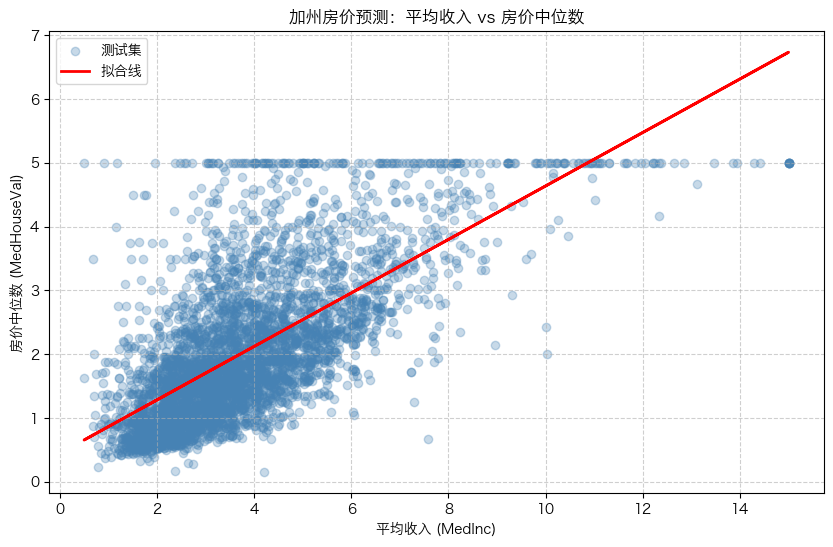

```python
# 创建一块画布
plt.figure(figsize=(10, 6))

# 绘制测试集的实际数据散点 (使用较浅的颜色，方便看清高密度区域)
plt.scatter(X_test, y_test, color='steelblue', alpha=0.3, label='测试集')

# 绘制模型预测出的那条“直线”
plt.plot(X_test, y_pred, color='red', linewidth=2, label='拟合线')

# 添加图表信息
plt.xlabel('平均收入 (MedInc)')
plt.ylabel('房价中位数 (MedHouseVal)')
plt.title('加州房价预测：平均收入 vs 房价中位数')
plt.legend()
plt.grid(True, linestyle='--', alpha=0.6)

# 显示图像
plt.show()
```

注意到存在数据截断问题，房价中位数被限制在了50万美元。

下一个的方法中，我们会剔除掉这些数据。

### 多元线性回归

多元线性回归是线性回归的扩展，允许我们使用多个特征来预测目标变量 $$ \hat{y} = \beta_0 + \beta_1 x_1 + \beta_2 x_2 + ... + \beta_n x_n $$

```python
# 剔除房价中位数为 5.0 (50万美元) 的数据点，避免数据截断带来的影响
df_filtered = df[df['MedHouseVal'] < 5.0]

# 提取特征变量(多个特征)和目标变量
X = df_filtered[['MedInc', 'HouseAge', 'AveRooms', 'AveBedrms', 'Population', 'AveOccup', 'Longitude', 'Latitude']]
y = df_filtered['MedHouseVal']

# 划分训练集和测试集
X_train, X_test, y_train, y_test = train_test_split(X, y, test_size=0.2, random_state=42)

# 构建和训练多元线性回归模型
linerNModel = LinearRegression()
linerNModel.fit(X_train, y_train)

# 预测和评估
y_pred = linerNModel.predict(X_test)
mse = mean_squared_error(y_test, y_pred)
r2 = r2_score(y_test, y_pred)

print(f"均方误差: {mse:.4f}\nR²得分: {r2:.4f}\n各项特征系数: {np.round(linerNModel.coef_, 4)}")
```

```
均方误差: 0.4133
R²得分: 0.5689
各项特征系数: [ 0.4283  0.008  -0.1036  0.5788  0.     -0.0031 -0.3922 -0.3758]
```

对于多元的数据，我们不能再用直接的X-y图了。但仍然可以将绘制y_real-y_pred图，具体来说，我们把测试集的点的真实值作为x轴，预测值作为y轴，画出散点图。理想情况下，这些点应该沿着45度的对角线分布。

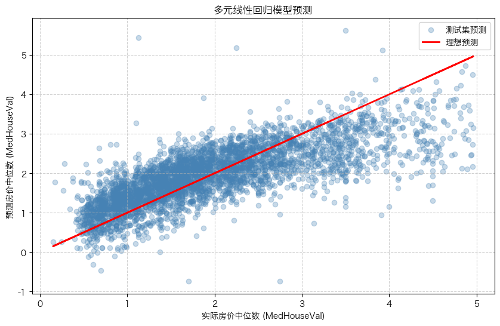

```python
plt.figure(figsize=(10, 6))
plt.scatter(y_test, y_pred, color='steelblue', alpha=0.3, label='测试集预测')
plt.plot(y_test, y_test, color='red', linewidth=2, label='理想预测')  # 理想情况下的45度线
plt.xlabel('实际房价中位数 (MedHouseVal)')
plt.ylabel('预测房价中位数 (MedHouseVal)')
plt.title('多元线性回归模型预测')
plt.legend()

plt.grid(True, linestyle='--', alpha=0.6)
plt.show()
```

这一次的拟合效果看起来明显好多了，虽然$R^2 = 0.56$仍然算不上好。 图中可以注意到，在高位房价的预测上，模型的预测值会更低一些，这种非线性特征自然地引出了下一个方法。

### 多项式回归

在单元回归中，我们假设特征与目标变量之间的关系是线性的，但在实际中，这种关系可能是非线性的。多项式回归通过引入特征的高次项来捕捉这种非线性关系。 $$ \hat{y} = \beta_0 + \beta_1 x + \beta_2 x^2 + ... + \beta_n x^n $$ 进一步地，我们也可以将多项式回归与多元线性回归结合起来，来捕捉多个特征之间的非线性关系。 $$ \hat{y} = \beta_0 + \beta_1 x_1 + \beta_2 x_2 + ... + \beta_n x_n \\ \beta_{11} x_1^2 + \beta_{22} x_2^2 + ... + \beta_{nn} x_n^2 + \\ \beta_{12} x_1 x_2 + \beta_{13} x_1 x_3 + ... + \beta_{(n-1)n} x_{n-1} x_n \\ ...... $$ sklearn中提供了PolynomialFeatures这个工具，可以方便地生成多项式特征。我们可以使用它来扩展我们的特征集，然后再进行线性回归。

```python
from sklearn.preprocessing import PolynomialFeatures

poly = PolynomialFeatures(degree=3, include_bias=False)
polymodel = LinearRegression()

X_poly = poly.fit_transform(X) # 展开特征到三次项并记忆规则
X_train, X_test, y_train, y_test = train_test_split(X_poly, y, test_size=0.2, random_state=42)
polymodel.fit(X_train, y_train)
y_pred = polymodel.predict(X_test)
mse = mean_squared_error(y_test, y_pred)
r2 = r2_score(y_test, y_pred)
print(f"均方误差: {mse:.4f}\nR²得分: {r2:.4f}")
```

```
均方误差: 0.3476
R²得分: 0.6375
```

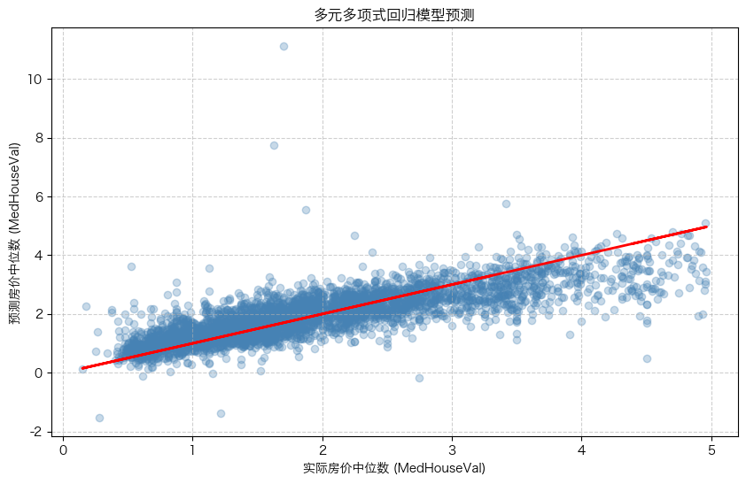

```python
plt.figure(figsize=(10, 6))
plt.scatter(y_test, y_pred, color='steelblue', alpha=0.3)
plt.plot(y_test, y_test, color='red', linewidth=2)  # 理想情况下的45度线
plt.xlabel('实际房价中位数 (MedHouseVal)')
plt.ylabel('预测房价中位数 (MedHouseVal)')
plt.title('多元多项式回归模型预测')
plt.grid(True, linestyle='--', alpha=0.6)
plt.show()
```

$R^2$提升到了0.64，数据点进一步密集了。不过我们之前观察到的偏离趋势并没有太大的变化（

## 分类算法

分类算法的核心目标是划定“决策边界”，将数据划分到离散的类别中（如：良性/恶性，垃圾邮件/正常邮件）。广泛应用于疾病诊断、用户流失预测、图像识别等场景。

**特征标准化** 为了将数据集中的不同特征放在同一尺度上，我们通常会进行特征标准化（Feature Scaling）。常用的方法为Z-score标准化： $$ x' = \frac{x - \mu}{\sigma} $$ 其中，$\mu$ 是特征的均值，$\sigma$ 是特征的标准差。通过标准化，我们可以加速模型的收敛，并且避免某些特征因为数值范围较大而主导模型的训练过程。

接下来，我们选择乳腺癌数据集来实践回归算法的应用。这个数据集包含了569个样本，每个样本有30个特征，目标变量是一个二分类标签（良性/恶性）。我们将使用逻辑回归来构建一个分类模型，并评估其性能。

### 逻辑回归 (Logistic Regression)

逻辑回归名带“回归”，实为基础且强大的**二分类算法**。它的核心思想是：先进行线性加权求和，再通过逻辑函数（Sigmoid 函数）将连续的输出挤压到 0 和 1 之间，从而输出属于正类的**概率值**。

第一步，计算线性组合 $z$： $$z = w_1 x_1 + w_2 x_2 + \dots + w_n x_n + b$$

第二步，使用 Sigmoid 函数将其映射为预测概率 $\hat{y}$： $$\hat{y} = \sigma(z) = \frac{1}{1 + e^{-z}}$$

[figure not shown]

通常以 0.5 为阈值，$\hat{y} \ge 0.5$ 判为正类（1），否则判为负类（0）。

#### 与深度学习的联系与参数优化：

从网络结构来看，逻辑回归等同于**一个带有 Sigmoid 激活函数的单层神经元**。由于 Sigmoid 的非线性特性，使得我们无法像纯线性回归那样通过矩阵运算直接求出**解析解 (Analytical Solution)**。因此，必须依赖**梯度下降 (Gradient Descent)** 等数值迭代算法来逐步寻优。

#### 对数损失 / 二元交叉熵 (Binary Cross-Entropy)

为了衡量预测概率 $\hat{y}$ 与真实标签 $y \in \{0, 1\}$ 的差距，逻辑回归引入了交叉熵作为损失函数： $$L(\mathbf{w}, b) = -\frac{1}{N} \sum_{i=1}^{N} [y_i \log(\hat{y}_i) + (1 - y_i) \log(1 - \hat{y}_i)]$$

在参数空间中，这个损失函数定义了一个**严格凸曲面 (Strictly Convex Surface)**。我们的梯度下降算法正是沿着这个曲面的最陡下坡（反梯度）方向不断更新参数，从而收敛至全局最小损失。

scikit-learn 中的 `LogisticRegression` 类实现了逻辑回归算法，支持多种优化方法（如：liblinear、lbfgs、sag、saga）来求解参数。通过调整正则化参数 `C` 和选择合适的优化器，我们可以在训练过程中有效地控制模型的复杂度和收敛速度。

```python
from sklearn.datasets import load_breast_cancer
from sklearn.preprocessing import StandardScaler
from sklearn.model_selection import train_test_split
from sklearn.linear_model import LogisticRegression
from sklearn.metrics import accuracy_score, recall_score, f1_score

# 加载乳腺癌数据集
breast_cancer = load_breast_cancer()
X = breast_cancer.data
y = breast_cancer.target
# 划分训练集和测试集
X_train, X_test, y_train, y_test = train_test_split(X, y, test_size=0.2, random_state=42)

# 标准化特征：只在训练集上 fit，再用于训练集和测试集 transform
scaler = StandardScaler()
X_train_scaled = scaler.fit_transform(X_train)
X_test_scaled = scaler.transform(X_test)

logModel = LogisticRegression(max_iter=3000, random_state=42)
logModel.fit(X_train_scaled, y_train)
y_pred = logModel.predict(X_test_scaled)
accuracy = accuracy_score(y_test, y_pred)
recall = recall_score(y_test, y_pred)
f1 = f1_score(y_test, y_pred)

print(f"模型准确率: {accuracy:.4f}")
print(f"恶性肿瘤召回率: {recall:.4f}, F1分数: {f1:.4f}")
print(f"迭代次数: {logModel.n_iter_[0]}")

# 对测试集中具体样本进行预测，并输出预测概率与实际标签
probabilities = logModel.predict_proba(X_test_scaled[:5])
for i, prob in enumerate(probabilities):  # 只展示前5个样本的预测
    print(f"样本 {i+1}: 预测恶性概率 = {100 * prob[0]:.2f}%, 实际标签 = {y_test[i]}")
```

```
模型准确率: 0.9737
恶性肿瘤召回率: 0.9859, F1分数: 0.9790
迭代次数: 20
样本 1: 预测恶性概率 = 11.36%, 实际标签 = 1
样本 2: 预测恶性概率 = 100.00%, 实际标签 = 0
样本 3: 预测恶性概率 = 99.69%, 实际标签 = 0
样本 4: 预测恶性概率 = 0.05%, 实际标签 = 1
样本 5: 预测恶性概率 = 0.01%, 实际标签 = 1
```

分数相当不错，但这种方法没什么可解释性……

### K近邻算法 (K-Nearest Neighbors, KNN)

K近邻算法是一种基于实例的学习方法，核心思想是：对于一个新的输入样本，找到训练集中与其距离最近的K个邻居，根据这些邻居的类别来进行预测。常用的距离度量包括欧氏距离、曼哈顿距离等，因此十分依赖于特征标准化。因为它不会提炼任何特征，且对噪声敏感，所以很少实际应用。

```python
from sklearn.neighbors import KNeighborsClassifier

knn = KNeighborsClassifier(n_neighbors=5)

knn.fit(X_train_scaled, y_train)
y_pred_knn = knn.predict(X_test_scaled)
accuracy_knn = accuracy_score(y_test, y_pred_knn)
recall_knn = recall_score(y_test, y_pred_knn)
f1_knn = f1_score(y_test, y_pred_knn)

print(f"KNN模型准确率: {accuracy_knn:.4f}")
print(f"KNN模型恶性肿瘤召回率: {recall_knn:.4f}, F1分数: {f1_knn:.4f}")
```

```
KNN模型准确率: 0.9474
KNN模型恶性肿瘤召回率: 0.9577, F1分数: 0.9577
```

对于多特征的肿瘤数据集，KNN的算法表现并不太理想

### 支持向量机 (Support Vector Machine, SVM)

支持向量机是一种强大的分类算法，旨在找到一个最优的超平面来最大化类别之间的间隔。SVM通过引入核函数（如线性核、多项式核、径向基函数核）来处理非线性可分的数据。SVM在高维空间中表现出色，尤其适用于文本分类和图像识别等任务。

SVM的核心思想是，在特征空间中找到一个超平面: $$ \mathbf{w}^T \mathbf{x} + b = 0 $$

这个超平面将数据切分为两类，我们标记为$y_i \in \{+1, -1\}$。我们希望这个超平面能够**最大化两类之间的间隔（Margin）**，从而提高模型的泛化能力。

并且我们希望对于样本点（$y_i, \mathbf{x}_i$），满足以下约束条件： $$ y_i (\mathbf{w}^T \mathbf{x}_i + b) \geq 1 $$

满足上述等式（即 $=1$ 或 $=-1$）的样本点被称为**支持向量 (Support Vectors)**。这些点决定了最终的模型。

#### 1. 优化目标与硬间隔 (Hard Margin)

两个异类支持向量到超平面的总距离，称为“间隔”。根据点到平面的距离公式，这个间隔为 $\gamma = \frac{2}{\|\mathbf{w}\|}$。 我们的目标是最大化间隔，这等价于最小化 $\frac{1}{2}\|\mathbf{w}\|^2$。 基本型求解问题如下： $$ \begin{aligned} \min_{\mathbf{w}, b} \quad & \frac{1}{2}\|\mathbf{w}\|^2 \\ \text{s.t.} \quad & y_i (\mathbf{w}^T \mathbf{x}_i + b) \geq 1, \quad i = 1, 2, \dots, N \end{aligned} $$

通过拉格朗日乘数法，这个问题可以转化为**对偶问题 (Dual Problem)** 求解。

#### 2. 软间隔 (Soft Margin) 与 惩罚参数 C

硬间隔要求所有样本必须被完美地正确分类，但这在现实数据中（含有噪声或异常值）常常导致无解或严重过拟合。 **软间隔**的引入允许少量样本点犯错。我们为每个样本引入一个**松弛变量 (Slack Variable)** $\xi_i \geq 0$： $$ y_i (\mathbf{w}^T \mathbf{x}_i + b) \geq 1 - \xi_i $$

此时的优化目标变成了： $$ \min_{\mathbf{w}, b, \xi} \quad \frac{1}{2}\|\mathbf{w}\|^2 + C \sum_{i=1}^{N} \xi_i $$

- **参数 $C$ 的作用**：在 sklearn 中的 `SVC(C=1.0)` 就是调整这个值。
  - **大 $C$**：对把点分错的惩罚极高，模型倾向于画更复杂的线来追求**训练集的高准确率**（易过拟合，间隔变小）。
  - **小 $C$**：允许更多点被分错，模型更看重**大间隔的平滑界限**（抗噪性好，可能会稍微欠拟合）。

#### 3. 核技巧 (Kernel Trick) 与非线性分类

当数据在原始空间绝对不能用一条直线（或平面）切开时（例如环形分布点），我们要把数据**映射到一个更高维的空间**中使其线性可分。即 $\mathbf{x} \rightarrow \phi(\mathbf{x})$。 但是，计算高维空间内积 $\phi(\mathbf{x}_i)^T \phi(\mathbf{x}_j)$ 计算量极大，会引发“维数灾难”。

**核技巧**的神奇之处在于：我们找一个核函数 $\kappa(\mathbf{x}_i, \mathbf{x}_j) = \phi(\mathbf{x}_i)^T \phi(\mathbf{x}_j)$。通过核函数，我们不需要知道高维映射 $\phi(\mathbf{x})$ 的具体形式，就能直接在低维空间计算出它们在高维的内积！

常见的核函数 (sklearn 中的 `kernel` 参数)：

1. **Linear (线性核)**：天然适用于高维稀疏特征（如文本分类）。
2. **Poly (多项式核)**：增加多项式组合特征。
3. **RBF (径向基核/高斯核)**：$\kappa(\mathbf{x}_i, \mathbf{x}_j) = \exp(-\gamma \|\mathbf{x}_i - \mathbf{x}_j\|^2)$。它实际上将数据映射到了无穷维！通过调参 $\gamma$ (gamma)，它可以拟合几乎任何复杂的非线性边界，是应用最广的核函数。

```python
from sklearn.svm import SVC

svmModel = SVC(kernel='rbf', random_state=42)
svmModel.fit(X_train_scaled, y_train)
y_pred_svm = svmModel.predict(X_test_scaled)
accuracy_svm = accuracy_score(y_test, y_pred_svm)
recall_svm = recall_score(y_test, y_pred_svm)
f1_svm = f1_score(y_test, y_pred_svm)

print(f"SVM模型准确率: {accuracy_svm:.4f}")
print(f"SVM模型恶性肿瘤召回率: {recall_svm:.4f}, F1分数: {f1_svm:.4f}")
```

```
SVM模型准确率: 0.9825
SVM模型恶性肿瘤召回率: 1.0000, F1分数: 0.9861
```

### 决策树 (Decision Tree)

决策树是一种少有的“白盒”模型，其决策过程可以被解释。决策树不断根据特征进行二分，最后形成一个树状结构。有以下节点类型：

1. **Root Node (根节点)**: 决策树的起始点，包含所有训练样本。
2. **Internal Node (内部节点)**: 根据某个特征的值进行条件判断（例如：面积 <= 100?），将数据进一步分割成子集。
3. **Leaf Node (叶节点)**: 决策树的末端，不再进行分割，它代表了最终的类别预测结果（例如：预测为“良性”或“恶性”）。

衡量纯度的常用指标是 **Gini不纯度**（也可以用信息熵，不过这个我们很熟悉了）： $$ Gini = 1 - \sum_{k=1}^{K} p_k^2, \text{where } k \text{ is the number of classes} $$ 其中 $K$ 是类别数量，$p_k$ 是该节点中属于第 $k$ 类的样本比例。

- 当所有样本属于同一类时，$Gini = 0$（完美纯净）。
- 当样本均匀分布在各类别时（比如一半恶性一半良性），$Gini$ 达到最大值（0.5）。

决策树的算法（如 CART）会遍历当前所有可用的特征及其可能的值，计算**切分后子节点加权平均的 Gini 不纯度**，并**选择使 Gini 下降幅度最大的那个特征和切分点**。这是一个贪心算法，会递归进行，直到满足停止条件。否则，决策树可能会过拟合训练数据（例如：每个样本都成为一个叶节点）。因此，我们通常会设置一些限制条件，如：

- **max_depth**: 树的最大深度。
- **min_samples_split**: 内部节点再划分所需的最小样本数。

为了方便比较，我们还是采用相同的标准化数据集。

```
决策树模型准确率: 0.9474
决策树模型恶性肿瘤召回率: 0.9718, F1分数: 0.9583
```

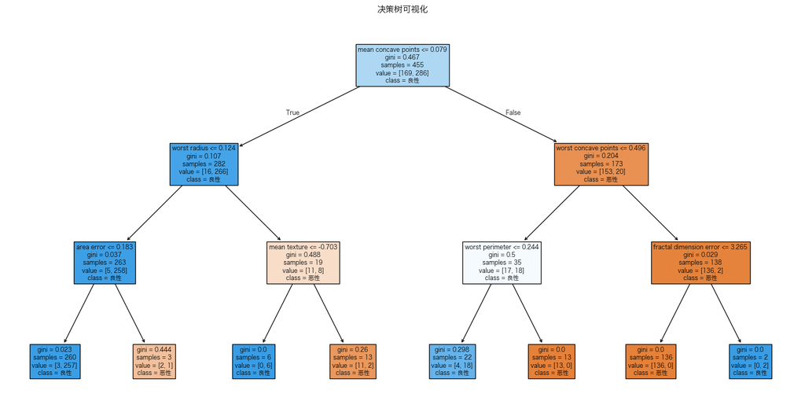

```python
from sklearn.tree import DecisionTreeClassifier, plot_tree
# 3-layer model
treeModel = DecisionTreeClassifier(max_depth=3,random_state=42)
treeModel.fit(X_train_scaled, y_train)
y_pred_tree = treeModel.predict(X_test_scaled)
accuracy_tree = accuracy_score(y_test, y_pred_tree)
recall_tree = recall_score(y_test, y_pred_tree)
f1_tree = f1_score(y_test, y_pred_tree)
print(f"决策树模型准确率: {accuracy_tree:.4f}")
print(f"决策树模型恶性肿瘤召回率: {recall_tree:.4f}, F1分数: {f1_tree:.4f}")
# plot and analysis
plt.figure(figsize=(20, 10))
plot_tree(
treeModel, filled=True, feature_names=breast_cancer.feature_names, class_names= ['恶性', '良性']
)
plt.title("决策树可视化")
plt.show()
```

只需要三层决策树就已经可以达到94.7%的准确率，接下来我们解释这个决策树。 **第一层（根节点，深度为0）：**

- **判断条件:** `mean concave points <= 0.079` (平均凹点数 <= 0.079)。这是模型认为用来区分良恶性**最重要（信息增益最大）**的特征。标准化的数值具有特定的刻度。
- 如果为 **True**（向左走）：样本属于相对较轻微的病理特征，倾向于“良性”。
- 如果为 **False**（向右走）：样本包含较多的凹点，具有更强的恶性倾向。该节点中恶性样本比例极高。

**第二层（内部节点，深度为1）：**

- **左侧判断:** `worst radius <= 0.124` (最大半径 <= 0.124)。结合了之前的指标，现在模型在检查最大的肿瘤半径。
- **右侧判断:** `worst concave points <= 0.496` (最大凹点数 <= 0.496)。对于之前判定较危险的样本，模型继续检查最大凹点数特征来进行细分。

**第三层（内部节点，深度为2）：**

- **左侧分支的判断:** 分别又检查了 `area error` (面积误差) 和 `mean texture` (平均纹理)。
- **右侧分支的判断:** 分别检查了 `worst perimeter` (最大周长) 和 `fractal dimension error` (分形维数误差)。

**叶节点（最终分类）：** 图中最底部的一排框就是叶节点。每一个叶节点中，`value = [恶性数量, 良性数量]` 决定了该路径最终的投票结果，多数决即为 `class`。 例如最左下角的深蓝色叶子节点：经过这三层特定的判断后，落入这个桶里的样本有 260 个，其中包含 3 个恶性，257 个良性，所以模型非常有信心地 (`gini = 0.023`，非常纯) 将这类样本预测为**良性**。

虽然具有更好的可解释性，但在特征高度连续，边界相对平滑的任务中，决策树的离散分割可能无法很好地拟合数据，表现不如SVM等方法。

### 随机森林

在决策树的基础上，随机森林通过**集成学习**的思想，构建了一个由多棵决策树组成的模型。每棵树都是在原始数据的**随机子样本**上训练的（通过**Bootstrap抽样**），并且在每个节点的分裂过程中，随机选择一部分特征进行考虑（而不是使用全部特征）从而可以训练出不同的决策树。最终，随机森林通过对所有树的预测结果进行投票（分类）或平均（回归）来得到最终的预测结果。

```python
from sklearn.ensemble import RandomForestClassifier

rfModel = RandomForestClassifier(
    n_estimators=150,
    max_features='sqrt',
    oob_score=True,
    random_state=42)

rfModel.fit(X_train_scaled, y_train)
print(f"袋外准确率: {rfModel.oob_score_:.4f}")
y_pred_rf = rfModel.predict(X_test_scaled)
accuracy_rf = accuracy_score(y_test, y_pred_rf)
recall_rf = recall_score(y_test, y_pred_rf)
f1_rf = f1_score(y_test, y_pred_rf)
print(f"随机森林模型准确率: {accuracy_rf:.4f}")
print(f"随机森林模型恶性肿瘤召回率: {recall_rf:.4f}, F1分数: {f1_rf:.4f}")
```

```
袋外准确率: 0.9516
随机森林模型准确率: 0.9649
随机森林模型恶性肿瘤召回率: 0.9859, F1分数: 0.9722
```

虽然随机森林准确率确实高于单颗决策树，但仍然不能超越svm方法。在乳腺癌数据集这种特征连续且边界相对平滑的任务中，随机森林虽然通过集成多个树来提升了模型的稳定性和准确率，但它仍然无法捕捉到SVM所能拟合的复杂非线性边界。